# rcprd: An R package to simplify the extraction and processing of CPRD data, and create analysis-ready datasets

*This article does not contain any real patient data. All patient data has been simulated but formatted to match the structure of CPRD Aurum data.*

# 1 Introduction

The Clinical Practice Research Datalink (CPRD) is a large resource of Electronic Health Records from the UK, owned by the UK Medicines and Healthcare products Regulatory Agency (MHRA), and containing information on demography, medical history, test results and drug use of individuals registered with a general practice. The MHRA maintain two databases, CPRD GOLD, (Herrett et al. 2015) which contains data from general practices using the Vision computer system, and CPRD Aurum (Wolf et al. 2019), which contains data from general practices using the Egton Medical Information Systems (EMIS) computer system, EMIS Web. The primary care data is linked to hospital data, death registration data, cancer registry data, deprivation data and mental health services data, enabled by NHS digital.(Padmanabhan et al. 2019) As of 2016, the EMIS Web computer system was used by 4199 (56%) of the general practices in England.(Kontopantelis et al. 2018) As of September 2024, CPRD Aurum contained data on 47 million (16 million currently registered) individuals from 1,784 (1,596 currently contributing) general practices across the United Kingdom,(CPRD 2024a) and CPRD GOLD contained data on 21 million (2.9 million currently registered) individuals.(CPRD 2024b) CPRD is a widely used resource: since 2019, a PubMed search reveals there have been 540 studies published which contain “CPRD” in the title or abstract. Extraction of CPRD data and transformation into a format ready for statistical analysis is computationally demanding and requires a significant amount of work. There is limited published software available to aid researchers in the extraction and processing of CPRD data.Yimer et al. (2021)

**rEHR** (Springate et al. 2017) is an R package for manipulating and analysing electronic health record data, which works by creating an SQLite database on a fixed storage device (i.e. a disk drive), which is then subsequently queried to extract relevant information, faster than with conventional statistical analysis software. **rEHR** was designed to be database agnostic, and contains functionality for longitudinal data extraction, cutting data by time-varying covariates, matching controls to cases, converting the units of test data, and creating clinical code lists. **rEHR** is however no longer maintained, it works with an older version of R (3.3.2) and has been archived on CRAN. The **aurumpipeline** package (The Health Foundation Analytics Lab 2021) contains functions to clean and process CPRD Aurum data, which works by storing the data as parquet files on the disk drive, which are then subsequently queried to extract relevant data. However, **aurumpipeline** is not available on CRAN and is not provided with any reproducible examples. The R package **drugprepr** (Yimer et al. 2021) implements the algorithm of Pye et al. (2018) for preparing drug exposure data extracted from CPRD, however it does not deal with the initial data extraction and storing of data.

Given the many studies using CPRD data, and the limited availability software for data processing, this indicates that a large amount of research time is being spent duplicating the work of others in order to extract CPRD data. This study introduces **rcprd**, an R package designed to assist researchers in working with CPRD Aurum data and creating datasets which are ‘analysis-ready’. The main problem when working with CPRD Aurum data is the size of the raw data. Data on over 47 million individuals results in thousands of raw .txt files, and Terabytes of data, which can be cumbersome to work with. This is a particular issue for R users, as its infeasible to read all this data into the R workspace simultaneously, as R operates using physical memory (RAM). As suggested by Springate et al. (2017), **rcprd** bypassess this problem by creating an SQLite database which can then be queried for data of interest in order to build an analysis-ready dataset. **rcprd** then simplifies the process of querying the SQLite database with functions to extract variables such as “most recent test result”, “time until first event”, or “history of a specified condition”. The SQLite database must be created on a secure device or server which aligns with the data storage requirements of CPRD.

We start by discussing the structure of CPRD Aurum data and the approach taken by **rcprd** for processing this data, which draws heavily on the work of Springate et al. (2017). We then run through a worked example to showcase the functionality of **rcprd**, which has two main groups of functions. The first are to extract and store the data in a consistent manner. The second group is to query this data to extract patient level variables. We focus on CPRD Aurum, as opposed to CPRD GOLD, given there has been a considerable drop in the number of practices utilising Vision software in the last 10 years, limiting the research utility of the CPRD GOLD database. However, the **rcprd** package can also be used to manage linked secondary care (HES) and ONS death data, and is flexible to the point that it could be used to extract and store data from any electronic health record, which will be touched on in the discussion.

# 2 Data Structure and Extraction Process

## 2.1 Structure of CPRD Aurum data

We first define the terminology which will be used throughout this article:

- *Raw data*: The raw data provided to the user by CPRD.
- *Cohort*: A cohort of individuals that meet the inclusion/exclusion criteria for a given research question. In this setting, the cohort is ultimately a vector of patient id’s.
- *Analysis-ready dataset*: A data frame to which statistical models can be fitted, with one row for each individual in the cohort, and a column for each variable of interest, for example, age at cohort entry, or most recent BMI score prior to cohort entry. For longitudinal analyses, such data frames can be concatenated, with a variable indicating the time point at which the data was extracted.

The raw CPRD Aurum data is split into eight different file types: Consultation, DrugIssue, Observation, Patient, Practice, Problem, Referral, Staff. The data specification is available here: (CPRD 2022). For most research questions, the relevant files are Patient, Observation and DrugIssue. The Patient file contains information about registration into the database, date of death or lost to follow up, year of birth and gender. This file will be required to define a cohort. The observation file contains all medical diagnoses and tests, while DrugIssue contains information on prescriptions. Medical observations are identified by their *medcodeid*, whereas prescriptions are identified through their *prodcodeid*.

In order to facilitate data transfer, this data is commonly split by CPRD into numerous smaller files. The different patient files are denoted by the string *set1*, *set2*, *set3* in the file name. Individuals in the same patient file will have the corresponding string (*setX*) in the files containing their medical or prescription data. However, there will be more than one Observation and DrugIssue file corresponding to each patient file. For example, the observation files for patients in *set1*, will have *set1* in their file name, and then an extra suffix 1, 2, 3, etc. The same is true for the DrugIssue files. The naming structure for these is as follows:

- aurum_allpatid_set$X$_extract_patient_001.txt
- aurum_allpatid_set$X$_extract_observation_0$Y$.txt
- aurum_allpatid_set$X$_extract_drugissue_0$Y$.txt

where $X\in{1,2,3,...}$ and $Y\in{01,02,03,...}$. Note that the prefix to the file names may vary (i.e. the ‘aurum_allpatid’ part) however we expect the naming convention with regards to ‘set$X$’, file type, and ‘0$Y$’ to remain consistent. If this changes in the future, we will endeavour to update the **rcprd** as soon as possible.

## 2.2 Recommended process for extraction

Our recommended process for developing an analysis-ready dataset is as follows:

- Step 1: Extract initial cohort using extract_cohort() and apply initial inclusion/exclusion criteria which can be applied using only the patient file.
- Q1: Do the inclusion/exclusion criteria depend on primary care data?
  - If yes -> (proceed to step 2)
  - If no -> (proceed to Q2)
- Step 2: For patients that meet inclusion/exclusion criteria from step 1, add relevant primary care data into an SQLite database using cprd_extract().
- Step 3: Query SQLite database in order to apply further inclusion/exclusion criteria.
- Q2: Do the inclusion/exclusion criteria depend on linked data?
  - If yes -> (proceed to step 4)
  - If no -> (proceed to step 5)
- Step 4: Request type 1 linked data$^*$ for individuals and apply remaining inclusion/exclusion criteria.
- Step 5: For patients in the final cohort, add relevant primary care data into an SQLite database using cprd_extract(). If an SQLite database was already created in step 2, and only a small number of individuals were excluded in steps 3 and 4, consider skipping this step. However, if a large number of individuals were excluded, it is worthwhile to create the new SQLite database, as it will be much smaller and future queries for extracting variables will run much quicker.
- Step 6: Query this SQLite database for specific codes and tests to create variables for each individual in the cohort. These are stored as .rds objects, which R data analysts will be familiar with.
- Step 7: Combine extracted variables into an analysis-ready dataset, also stored as an .rds object.

$^*$type 1 linked data is defined as “linked data required in order to finalise the study population”

This process aligns with the process implemented by CPRD when cohort inclusion/exclusion criteria are dependent on linked data (see Q2 and step 4). The process can be done entirely within R using rcprd functions, without any specialist understanding of SQLite databases. We recommend this process because once set up, querying the SQLite database is computationally much quicker than reading each of the raw files into the R workspace and querying these separately. It also reduces the probability of errors induced from creating numerous loops through the raw data files. We now move onto a worked example, where we showcase how to implement the above process using **rcprd** and the functions which are detailed in Table 1.

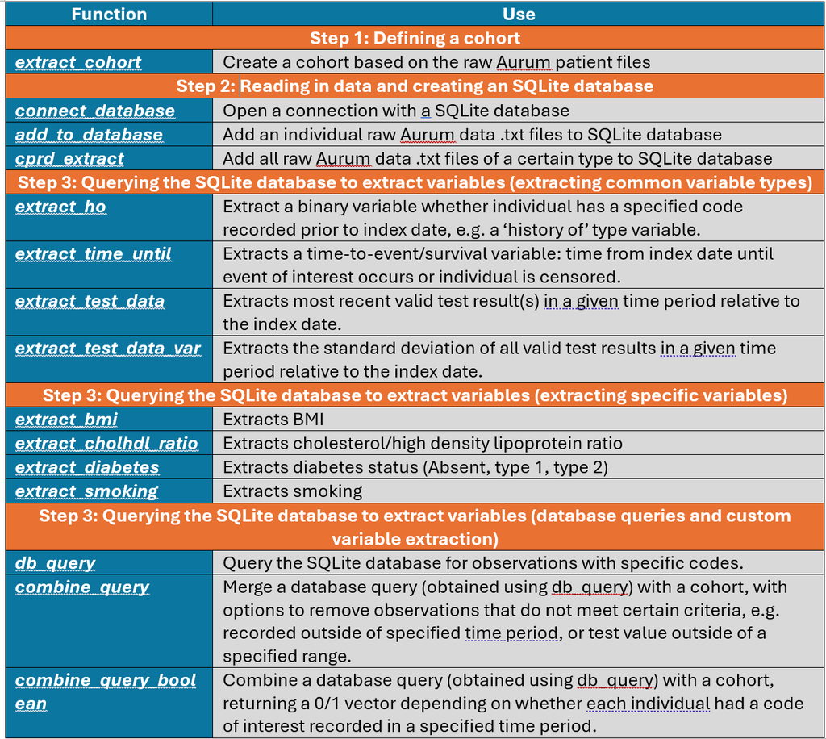

Table 1: Table of rcprd functions

# 3 Worked example for data extraction

## 3.1 Steps 1 - 4: Defining a cohort

We have provided simulated patient, observation and drugissue files which will be utilisied in the worked example. The names of the files share the same naming convention given in section 2.1, and column names of the data match the real Aurum data. Numeric variables were simulated at random as integers between 1 and 100, date variables as a date between 01/01/1900 and 01/01/2000, gender as an integer 1 or 2, and year of birth as an integer between 1900 and 2000. Patient id and practice id were assigned manually. These files are contained in the *inst/aurum_data* directory of **rcprd**. After installing **rcprd**, this directory can be accessed using the command `system.file("aurum_data", package = "rcprd")`. This contains data on 12 fake patients, split across two patient files (*set1* and *set2*) and three observation and drugissue files (all *set1*):

```r
#devtools::install_github("alexpate30/rcprd")
#install.packages("rcprd") NOT YET ON CRAN
library(rcprd)
#devtools::load_all()
list.files(system.file("aurum_data", package = "rcprd"), pattern = ".txt")
```

```
#>  [1] "aurum_allpatid_extract_practice_001.txt"
#>  [2] "aurum_allpatid_extract_practice_002.txt"
#>  [3] "aurum_allpatid_set1_extract_drugissue_001.txt"
#>  [4] "aurum_allpatid_set1_extract_drugissue_002.txt"
#>  [5] "aurum_allpatid_set1_extract_drugissue_003.txt"
#>  [6] "aurum_allpatid_set1_extract_observation_001.txt"
#>  [7] "aurum_allpatid_set1_extract_observation_002.txt"
#>  [8] "aurum_allpatid_set1_extract_observation_003.txt"
#>  [9] "aurum_allpatid_set1_extract_patient_001.txt"
#> [10] "aurum_allpatid_set2_extract_patient_001.txt"
```

The first step in most analyses is creating and defining a cohort of individuals, which will involve working with the patient files. Data from the patient files can be combined using the `extract_cohort()` function. This will look in the directory specified through the `filepath` argument, for any file containing “patient” in the file name. All files will be read in and concatenated into a single dataset. In some circumstances, researchers may be provided with a list of patids which meet their inclusion/exclusion criteria. In this case, these can be specified through the `patids` argument (which requires a character vector). Suppose the individuals meeting the exclusion criteria are those with patid = 1, 3, 4 and 6. We would then specify:

```r
pat <- extract_cohort(filepath = system.file("aurum_data", package = "rcprd"), patids = as.character(c(1,3,4,6)))
str(pat)
```

```
#> 'data.frame':    4 obs. of  12 variables:
#>  $ patid         : chr  "1" "3" "4" "6"
#>  $ pracid        : int  49 98 53 54
#>  $ usualgpstaffid: chr  "6" "43" "72" "11"
#>  $ gender        : int  2 1 2 1
#>  $ yob           : int  1984 1930 1915 1914
#>  $ mob           : int  NA NA NA NA
#>  $ emis_ddate    : Date, format: "1976-11-21" "1972-06-01" ...
#>  $ regstartdate  : Date, format: "1940-07-24" "1913-07-02" ...
#>  $ patienttypeid : int  58 81 10 85
#>  $ regenddate    : Date, format: "1996-08-25" "1997-04-24" ...
#>  $ acceptable    : int  1 1 0 1
#>  $ cprd_ddate    : Date, format: "1935-03-17" "1912-04-27" ...
```

In other circumstances, a user may need to apply the inclusion and exclusion criteria themselves. In this case, one would initially create a patient file for all individuals.

```r
pat <- extract_cohort(filepath = system.file("aurum_data", package = "rcprd"))
str(pat)
```

```
#> 'data.frame':    12 obs. of  12 variables:
#>  $ patid         : chr  "1" "2" "3" "4" ...
#>  $ pracid        : int  49 79 98 53 62 54 49 79 98 53 ...
#>  $ usualgpstaffid: chr  "6" "11" "43" "72" ...
#>  $ gender        : int  2 1 1 2 2 1 2 1 1 2 ...
#>  $ yob           : int  1984 1932 1930 1915 1916 1914 1984 1932 1930 1915 ...
#>  $ mob           : int  NA NA NA NA NA NA NA NA NA NA ...
#>  $ emis_ddate    : Date, format: "1976-11-21" "1979-02-14" ...
#>  $ regstartdate  : Date, format: "1940-07-24" "1929-02-23" ...
#>  $ patienttypeid : int  58 21 81 10 45 85 58 21 81 10 ...
#>  $ regenddate    : Date, format: "1996-08-25" "1945-03-19" ...
#>  $ acceptable    : int  1 0 1 0 0 1 1 0 1 0 ...
#>  $ cprd_ddate    : Date, format: "1935-03-17" "1932-02-05" ...
```

Often this then needs to be merged with the practice file, which contains information such as the last date of data collection for the practice. The practice files can be read in and combined using the function `extract_practices()`,

```r
prac <- extract_practices(filepath = system.file("aurum_data", package = "rcprd"))
str(prac)
```

```
#> 'data.frame':    6 obs. of  4 variables:
#>  $ pracid: int  49 53 54 62 79 98
#>  $ lcd   : Date, format: "1941-09-20" "1978-01-31" ...
#>  $ uts   : Date, format: NA NA ...
#>  $ region: int  48 51 54 9 7 48
```

and should then be merged with the patient file based on the `pracid` variable:

```r
pat <- merge(pat, prac, by.x = "pracid", by.y = "pracid")
```

The cohort of individuals would then be defined by applying study specific inclusion/exclusion criteria. For example, all individuals with > 1 day valid follow up aged 65+, after 1st January 2000. Such criteria can be applied solely using the information available in patient files. In this example, we define the individuals that met the inclusion criteria to be those with patid = 1, 3, 4 and 6.

```r
pat <- subset(pat, patid %in% c(1,3,4,6))
```

Once the cohort has been defined, we recommended saving this as an .rds file so it can be easily accessed, as it will be required as input for many of the subsequent functions. In this hypothetical example the inclusion/exclusion criteria are not dependent on linked data or primary care data, and therefore we jump to step 5. However, if the answer to Q1 was yes, resulting in the implementation of step 2, the process for creating the SQLite database (step 2) and querying this to apply the inclusnio/exclusion criteria (step 3) will follow the exact same processes as outlined in sections 3.2 and 3.3. If the answer to Q2 was yes, and type 1 linked data is required to apply the inclusion/exclusion criteria, this can be done without the use of **rcprd** or an SQLite database. Type 1 linked data is normally provided as a single text file, which can be readily loaded into R and manipulated in order to apply the criteria.

## 3.2 Step 5: Reading in data and creating an SQLite database

Step 5 reads in the medical/prescription data from the raw .txt files and adds this into a SQLite database. This will only be done for individuals meeting the inclusion/exclusion criteria. The SQLite database is stored on a fixed storage device and will be subsequently queried when extracting variables to create an analysis-ready dataset.

### 3.2.1 Add individual files to SQLite database using `add_to_database`

The function `add_to_database` can be used to add individual files to the SQLite database. Start by defining and connecting to your SQLite database. In this article we create a temporary database, but in practice this would be a permanent storage location. Specifically, `file.path(tempdir(), "temp.sqlite")` would be replaced by the desired file path and SQLite database name.

```r
aurum_extract <- connect_database(file.path(tempdir(), "temp.sqlite"))
```

Next, we add medical diagnoses data from the observation files to this database using the `add_to_database` function. It is imperative that when adding raw CPRD data to an SQLite database, that the SQLite database itself is stored in a secure environment which aligns with the data storage requirements of CPRD. The simulated raw data provided with **rcprd** can be accessed using the `system.file` function. The vector of patient id’s that defines the cohort is defined through the `subset_patids` argument. Only data with patid’s matching this argument will be added to the SQLite database. The `filetype` argument will select an appropriate function for reading in the .txt files, and also defines the name of the table in the SQLite database that the files are added to. Note that for the first file, `overwrite = TRUE` is specified to create a new table. For the second and third file, `append = TRUE` is specified to append to an existing table.

```r
add_to_database(filepath = system.file("aurum_data", "aurum_allpatid_set1_extract_observation_001.txt", package = "rcprd"),
                filetype = "observation", subset_patids = c(1,3,4,6), db = aurum_extract, overwrite = TRUE)
add_to_database(filepath = system.file("aurum_data", "aurum_allpatid_set1_extract_observation_002.txt", package = "rcprd"),
                filetype = "observation", subset_patids = c(1,3,4,6), db = aurum_extract, append = TRUE)
add_to_database(filepath = system.file("aurum_data", "aurum_allpatid_set1_extract_observation_003.txt", package = "rcprd"),
                filetype = "observation", subset_patids = c(1,3,4,6), db = aurum_extract, append = TRUE)
```

```r
db_query(db_open = aurum_extract, tab = "observation", n = 3)
```

```
#>     patid consid pracid  obsid    obsdate  enterdate staffid parentobsid
#>    <char> <char>  <int> <char>     <Date>     <Date>  <char>      <char>
#> 1:      1     33      1    100 1926-05-21 1967-04-13      79          95
#> 2:      1     66      1     46 1932-04-08 1928-04-19      34          17
#> 3:      1     41      1     53 1915-03-29 1994-03-21      35          79
#>            medcodeid value numunitid obstypeid numrangelow numrangehigh
#>               <char> <num>     <int>     <int>       <num>        <num>
#> 1:   498521000006119    48        16        20          28           86
#> 2:         401539014    22         1         2          27            8
#> 3: 13483031000006114    17        78        13          87           41
#>    probobsid
#>       <char>
#> 1:        54
#> 2:        35
#> 3:        74
```

Next, the prescription data from the drugissue files is added to a table called `drugissue`. A single SQLite database may contain more than one table, so this data is added to a different table within the same SQLite database. The table will take the same name as the `filetype` argument, unless the `table_name` argument is specified.

```r
add_to_database(filepath = system.file("aurum_data", "aurum_allpatid_set1_extract_drugissue_001.txt", package = "rcprd"),
                filetype = "drugissue", subset_patids = c(1,3,4,6), db = aurum_extract, overwrite = TRUE)
add_to_database(filepath = system.file("aurum_data", "aurum_allpatid_set1_extract_drugissue_002.txt", package = "rcprd"),
                filetype = "drugissue", subset_patids = c(1,3,4,6), db = aurum_extract, append = TRUE)
add_to_database(filepath = system.file("aurum_data", "aurum_allpatid_set1_extract_drugissue_003.txt", package = "rcprd"),
                filetype = "drugissue", subset_patids = c(1,3,4,6), db = aurum_extract, append = TRUE)
```

This table can be queried in the same way, changing the `tab` argument, which specifies the name of the table in the SQLite database to query:

```r
db_query(db_open = aurum_extract, tab = "drugissue", n = 3)
```

```
#>     patid issueid pracid probobsid drugrecid  issuedate  enterdate staffid
#>    <char>  <char>  <int>    <char>    <char>     <Date>     <Date>  <char>
#> 1:      1      93      1        88        83 1925-11-15 1967-03-25      98
#> 2:      1      93      1        55        59 1933-07-12 1934-09-07      88
#> 3:      1      16      1        22        82 1946-03-31 1960-04-20      50
#>          prodcodeid dosageid quantity quantunitid duration estnhscost
#>              <char>   <char>    <num>       <int>    <int>      <num>
#> 1: 3092241000033113       58       18          33       27         12
#> 2:   92041000033111       62       93          83       59         11
#> 3:  971241000033111       87       43          83       88         65
```

Listing the tables in the SQLite database shows there are now two, named *observation* and *drugissue*.

```r
RSQLite::dbListTables(aurum_extract)
```

```
#> [1] "drugissue"   "observation"
```

The `add_to_database` function allows specification of `filetype = c("observation", "drugissue", "referral", "problem", "consultation", "hes_primary","death")`, each corresponding to a specific function for reading in the corresponding .txt files with correct formatting. The `"hes_primary"` options correspond to the primary diagnoses file in linked HES APC data. The `"death"` file corresponds to the death file in the linked ONS data. If wanting to add other files to the SQLite database, a user defined function for reading in the raw .txt file can be specified through `extract_txt_func`. This allows the user to add any .txt file to their SQLite database.

Finally, when manually adding files in this manner, it is good practice to close the connection to the SQLite database once finished.

```r
RSQLite::dbDisconnect(aurum_extract)
```

### 3.2.2 Add all relevant files to SQLite database using `cprd_extract`

In practice, there will be a high number of files to add to the SQLite database and adding each one using `add_to_database` would be cumbersome. We now repeat the extraction but using the `cprd_extract` function, which is a wrapper for `add_to_database`, and will add all the files in a specified directory that contain a string matching the specified file type. Start by creating a connection to the database:

```r
aurum_extract <- connect_database(file.path(tempdir(), "temp.sqlite"))
```

We then use `cprd_extract` to add all the observation files into the SQLite database. If the connection (`aurum_extract`) is to an existing database, which is the case here, it will be overwritten when running `cprd_extract`. The directory containing the files should be specified using `filepath`. It will only read in and add files with the text string specified in `filetype` in their file name. The `filetype` argument takes values in `c("observation", "drugissue", "referral", "problem", "consultation")`. We then query the first three rows of this database, and note they are the same as previously.

```r
### Extract data
cprd_extract(db = aurum_extract,
             filepath = system.file("aurum_data", package = "rcprd"),
             filetype = "observation", subset_patids = c(1,3,4,6), use_set = FALSE)
```

```
#>   |                                                                              |                                                                      |   0%
#> Adding C:/Users/mbrxsap3/AppData/Local/Temp/RtmpcBcD0Y/Rinst62ec6b1d546d/rcprd/aurum_data/aurum_allpatid_set1_extract_observation_001.txt 2025-09-07 14:17:07.624689
#>   |                                                                              |=======================                                               |  33%
#> Adding C:/Users/mbrxsap3/AppData/Local/Temp/RtmpcBcD0Y/Rinst62ec6b1d546d/rcprd/aurum_data/aurum_allpatid_set1_extract_observation_002.txt 2025-09-07 14:17:07.674504
#>   |                                                                              |===============================================                       |  67%
#> Adding C:/Users/mbrxsap3/AppData/Local/Temp/RtmpcBcD0Y/Rinst62ec6b1d546d/rcprd/aurum_data/aurum_allpatid_set1_extract_observation_003.txt 2025-09-07 14:17:07.710205
#>   |                                                                              |======================================================================| 100%
```

```r
### Query first three rows
db_query(db_open = aurum_extract, tab = "observation", n = 3)
```

```
#>     patid consid pracid  obsid    obsdate  enterdate staffid parentobsid
#>    <char> <char>  <int> <char>     <Date>     <Date>  <char>      <char>
#> 1:      1     33      1    100 1926-05-21 1967-04-13      79          95
#> 2:      1     66      1     46 1932-04-08 1928-04-19      34          17
#> 3:      1     41      1     53 1915-03-29 1994-03-21      35          79
#>            medcodeid value numunitid obstypeid numrangelow numrangehigh
#>               <char> <num>     <int>     <int>       <num>        <num>
#> 1:   498521000006119    48        16        20          28           86
#> 2:         401539014    22         1         2          27            8
#> 3: 13483031000006114    17        78        13          87           41
#>    probobsid
#>       <char>
#> 1:        54
#> 2:        35
#> 3:        74
```

The process is then repeated for the drugissue files.

```r
### Extract data
cprd_extract(db = aurum_extract,
             filepath = system.file("aurum_data", package = "rcprd"),
             filetype = "drugissue", subset_patids = c(1,3,4,6), use_set = FALSE)
```

```
#>   |                                                                              |                                                                      |   0%
#> Adding C:/Users/mbrxsap3/AppData/Local/Temp/RtmpcBcD0Y/Rinst62ec6b1d546d/rcprd/aurum_data/aurum_allpatid_set1_extract_drugissue_001.txt 2025-09-07 14:17:07.83238
#>   |                                                                              |=======================                                               |  33%
#> Adding C:/Users/mbrxsap3/AppData/Local/Temp/RtmpcBcD0Y/Rinst62ec6b1d546d/rcprd/aurum_data/aurum_allpatid_set1_extract_drugissue_002.txt 2025-09-07 14:17:07.877117
#>   |                                                                              |===============================================                       |  67%
#> Adding C:/Users/mbrxsap3/AppData/Local/Temp/RtmpcBcD0Y/Rinst62ec6b1d546d/rcprd/aurum_data/aurum_allpatid_set1_extract_drugissue_003.txt 2025-09-07 14:17:07.903042
#>   |                                                                              |======================================================================| 100%
```

```r
### List tables
RSQLite::dbListTables(aurum_extract)
```

```
#> [1] "drugissue"   "observation"
```

```r
### Query first three rows
db_query(db_open = aurum_extract, tab = "drugissue", n = 3)
```

```
#>     patid issueid pracid probobsid drugrecid  issuedate  enterdate staffid
#>    <char>  <char>  <int>    <char>    <char>     <Date>     <Date>  <char>
#> 1:      1      93      1        88        83 1925-11-15 1967-03-25      98
#> 2:      1      93      1        55        59 1933-07-12 1934-09-07      88
#> 3:      1      16      1        22        82 1946-03-31 1960-04-20      50
#>          prodcodeid dosageid quantity quantunitid duration estnhscost
#>              <char>   <char>    <num>       <int>    <int>      <num>
#> 1: 3092241000033113       58       18          33       27         12
#> 2:   92041000033111       62       93          83       59         11
#> 3:  971241000033111       87       43          83       88         65
```

```r
### Disconnect
RSQLite::dbDisconnect(aurum_extract)
```

The string in the file name to match on, function to read in the raw data, and the name of the table in the SQLite database, can be altered using the `str_match`, `extract_txt_func` and `table_name` arguments respectively. Note the use of `str_match` may be of particular importance if the naming convention of the raw data differs from what we have described above. The argument `rm_duplicates = TRUE` can be specified to de-duplicate records before adding into the SQLite database. This will increase computation time, and the derivation of many variables will not be effected by having duplicate records, so consider carefully whether it’s necessary to apply this step or not. There will also be the opportunity to de-duplicate the records later on when querying the data. Note that `cprd_extract` may run for a considerable period of time when working with the entire CPRD AURUM database, and therefore it is not recommended to run interactively. While creation of the SQLite database may be time consuming, subsequent queries will be far more efficient, so this is short term pain for a long term gain.

### 3.2.3 Add all relevant files to SQLite database in a computationally efficient manner using the `set` functionality.

When the number of patients in your cohort is very large (for example millions, or tens of millions), the `add_to_database` function may perform very slowly. This is because for each observation in the file being added to the SQLite database, `add_to_database` checks to see whether the patid is contained in the vector `subset_patids` (a vector of length 20,000,000 in our case). We can utilise the structure of the CPRD AURUM data to speed up this process. If data has the *set* naming convention (see section 2.1), we know that we only need to search for patids from `subset_patids`, that are in the corresponding patient file. For example, when reading in file *aurum_allpatid_set1_extract_observation_00Y.txt* (for any *Y*), we only need to search whether patid is in the vector of patids from `subset.patid`, that are also in *aurum_allpatid_set1_extract_patient_001.txt*, which is much smaller vector. This can reduce the computation time for `add_to_database` and `cprd_extract`.

To achieve this, the `subset_patids` object should be a data frame with two required columns. The first column should be `patid`, the second should be `set`, reporting the corresponding value of set which the patient belongs to. The first step is therefore to create a patient file, which has an extra variable `set`, the number following the text string *set* in the patient file containing data for that patient. When reading in the patient files to create a cohort, this can be done by specifying `set = TRUE`. In this example, all individuals in our cohort come from the file with string *set1*, and therefore this variable is the same for all individuals in this cohort, however this will not be the case in practice.

```r
pat <- extract_cohort(filepath = system.file("aurum_data", package = "rcprd"), patids = as.character(c(1,3,4,6)), set = TRUE)
pat
```

```
#>   patid pracid usualgpstaffid gender  yob mob emis_ddate regstartdate
#> 1     1     49              6      2 1984  NA 1976-11-21   1940-07-24
#> 3     3     98             43      1 1930  NA 1972-06-01   1913-07-02
#> 4     4     53             72      2 1915  NA 1989-04-24   1969-07-11
#> 6     6     54             11      1 1914  NA 1926-09-09   1970-08-28
#>   patienttypeid regenddate acceptable cprd_ddate set
#> 1            58 1996-08-25          1 1935-03-17   1
#> 3            81 1997-04-24          1 1912-04-27   1
#> 4            10 1951-09-05          0 1921-02-13   1
#> 6            85 1983-03-14          1 1963-08-27   1
```

The patient file read in is the same as previously, with the addition of the `set` column. This file can be reduced to just the `patid` and `set` columns, and used as the input to `subset_patids` when running the `add_to_database` and `cprd_extract` functions. When extracting data from observation files with *set1* in the name, it will only search for patient id’s with `set == 1` in the data.frame provided to `subset_patids`.

```r
### Create connection to SQLite database
aurum_extract <- connect_database(file.path(tempdir(), "temp.sqlite"))

### Add observation files
cprd_extract(db = aurum_extract,
             filepath = system.file("aurum_data", package = "rcprd"),
             filetype = "observation",
             subset_patids = pat,
             use_set = TRUE)
```

```
#>   |                                                                              |                                                                      |   0%
#> Adding C:/Users/mbrxsap3/AppData/Local/Temp/RtmpcBcD0Y/Rinst62ec6b1d546d/rcprd/aurum_data/aurum_allpatid_set1_extract_observation_001.txt 2025-09-07 14:17:08.180196
#>   |                                                                              |=======================                                               |  33%
#> Adding C:/Users/mbrxsap3/AppData/Local/Temp/RtmpcBcD0Y/Rinst62ec6b1d546d/rcprd/aurum_data/aurum_allpatid_set1_extract_observation_002.txt 2025-09-07 14:17:08.280758
#>   |                                                                              |===============================================                       |  67%
#> Adding C:/Users/mbrxsap3/AppData/Local/Temp/RtmpcBcD0Y/Rinst62ec6b1d546d/rcprd/aurum_data/aurum_allpatid_set1_extract_observation_003.txt 2025-09-07 14:17:08.393617
#>   |                                                                              |======================================================================| 100%
```

```r
### Add drugissue files
cprd_extract(db = aurum_extract,
             filepath = system.file("aurum_data", package = "rcprd"),
             filetype = "drugissue",
             subset_patids = pat,
             use_set = TRUE)
```

```
#>   |                                                                              |                                                                      |   0%
#> Adding C:/Users/mbrxsap3/AppData/Local/Temp/RtmpcBcD0Y/Rinst62ec6b1d546d/rcprd/aurum_data/aurum_allpatid_set1_extract_drugissue_001.txt 2025-09-07 14:17:08.487986
#>   |                                                                              |=======================                                               |  33%
#> Adding C:/Users/mbrxsap3/AppData/Local/Temp/RtmpcBcD0Y/Rinst62ec6b1d546d/rcprd/aurum_data/aurum_allpatid_set1_extract_drugissue_002.txt 2025-09-07 14:17:08.535124
#>   |                                                                              |===============================================                       |  67%
#> Adding C:/Users/mbrxsap3/AppData/Local/Temp/RtmpcBcD0Y/Rinst62ec6b1d546d/rcprd/aurum_data/aurum_allpatid_set1_extract_drugissue_003.txt 2025-09-07 14:17:08.570713
#>   |                                                                              |======================================================================| 100%
```

```r
### Query first three rows of each table
db_query(db_open = aurum_extract, tab = "observation", n = 3)
```

```
#>     patid consid pracid  obsid    obsdate  enterdate staffid parentobsid
#>    <char> <char>  <int> <char>     <Date>     <Date>  <char>      <char>
#> 1:      1     33      1    100 1926-05-21 1967-04-13      79          95
#> 2:      1     66      1     46 1932-04-08 1928-04-19      34          17
#> 3:      1     41      1     53 1915-03-29 1994-03-21      35          79
#>            medcodeid value numunitid obstypeid numrangelow numrangehigh
#>               <char> <num>     <int>     <int>       <num>        <num>
#> 1:   498521000006119    48        16        20          28           86
#> 2:         401539014    22         1         2          27            8
#> 3: 13483031000006114    17        78        13          87           41
#>    probobsid
#>       <char>
#> 1:        54
#> 2:        35
#> 3:        74
```

```r
db_query(db_open = aurum_extract, tab = "drugissue", n = 3)
```

```
#>     patid issueid pracid probobsid drugrecid  issuedate  enterdate staffid
#>    <char>  <char>  <int>    <char>    <char>     <Date>     <Date>  <char>
#> 1:      1      93      1        88        83 1925-11-15 1967-03-25      98
#> 2:      1      93      1        55        59 1933-07-12 1934-09-07      88
#> 3:      1      16      1        22        82 1946-03-31 1960-04-20      50
#>          prodcodeid dosageid quantity quantunitid duration estnhscost
#>              <char>   <char>    <num>       <int>    <int>      <num>
#> 1: 3092241000033113       58       18          33       27         12
#> 2:   92041000033111       62       93          83       59         11
#> 3:  971241000033111       87       43          83       88         65
```

Note that there is no difference compared to the previously extracted SQLite databases. The computational gains from applying the subsetting in this manner will not be realised in this example. We do not close the connection, as we will now move onto querying the database to extract variables for creating an analysis-ready dataset.

## 3.3 Step 6: Querying the SQLite database to extract variables

Once the data has been extracted and stored in an SQLite database, it can now be queried to create variables of interest. Please note, if the answer to Q1 was yes, resulting in the implementation of steps 2 and 3, the process for querying the SQLite database in order to apply the exclusion criteria (step 3) will follow the exact same process as outlined here.

The normal process for extracting variables from electronic health records is to create code lists, a group of codes which denote the same condition. The database would then be queried for observations with medical codes matching those in the code list. A `variable` would then be defined based on this query. Whether this is a binary variable, indicating whether an individual has any record of a given code, or the most recent test result with the given code, or something much more complex. In CPRD Aurum, medical diagnoses and tests are identified from the *observation* file using *medcodeids*, and prescription data is identified from the drugissue file using *prodcodeids*. Creation of code lists is an important step of data extraction, and we refer elsewhere for details on best practice for developing code lists, and the limitations of working with code lists (Williams et al. 2019, 2017; Watson et al. 2017; Gulliford et al. 2009; Matthewman et al. 2024). The functions in this section are split into three groups:

- Functions for extracting common variable types.
- Functions for extracting specific variables
- Functions for database queries and custom variable extraction

These functions extract and query the data relative to an *index date*. The index date may be a fixed date (e.g. 1st January 2010), a date which is different for each individual (e.g. date age 50 reached), or a combination of the two (e.g., maximum of 1st January 2010 and date aged 50 reached).

### 3.3.1 Functions for extracting common variable types

There are functions to extract three common variable types, history of condition/medication prior to index date (`extract_ho`), time from the index date until first occurrence of a medical code/prescription or censoring (`extract_time_until`), and most recent test result(s) in a given time frame and valid range relative to the index date (`extract_test_data`). Variables are calculated relative to the index date using the observation date (obsdate) in the observation file and the issue date (issuedate) in the drug issue file.

The first, `extract_ho`, extracts a binary variable based on whether individual has a specified code recorded prior to index date. This can be applied to search for history of medical diagnoses or prescriptions. The index date ust be a variable in the cohort dataset, and is specified through the `indexdt` argument.

```r
### Define codelist
my_vector_codelist <- "187341000000114"

### Add an index date to cohort
pat$fup_start <- as.Date("01/01/2020", format = "%d/%m/%Y")

### Extract a history of type variable using extract_ho
ho <- extract_ho(cohort = pat,
                 codelist_vector = my_vector_codelist,
                 indexdt = "fup_start",
                 db_open = aurum_extract,
                 tab = "observation",
                 return_output = TRUE)
ho
```

```
#>   patid ho
#> 1     1  0
#> 3     3  0
#> 4     4  0
#> 6     6  1
```

The second is `extract_time_until`, which defines a time-to-event/survival variable. This has two components, the time until the first record of a specified code or censoring, and an indicator for whether event was observed or censored. To derive a variable of this type the cohort must also contain a time until censoring variable, which can be specified through `censdt`.

```r
### Add an censoring date to cohort
pat$fup_end <- as.Date("01/01/2024", format = "%d/%m/%Y")

### Extract a time until variable using extract_time_until
time_until <- extract_time_until(cohort = pat,
                                 codelist_vector = my_vector_codelist,
                                 indexdt = "fup_start",
                                 censdt = "fup_end",
                                 db_open = aurum_extract,
                                 tab = "observation",
                                 return_output = TRUE)
time_until
```

```
#>   patid var_time var_indicator
#> 1     1     1461             0
#> 2     3     1461             0
#> 3     4     1461             0
#> 4     6     1461             0
```

```r
### Extract test data using extract_test_data
test_data <- extract_test_data(cohort = pat,
                          codelist_vector = my_vector_codelist,
                          indexdt = "fup_start",
                          db_open = aurum_extract,
                          time_post = 0,
                          time_prev = Inf,
                          return_output = TRUE)
test_data
```

```
#>   patid value
#> 1     1    NA
#> 2     3    NA
#> 3     4    NA
#> 4     6    28
```

More than one observation can be returned by specifying `numobs`. Metadata of the test result, such as the unit of measurement, date recorded, and the medical code, can be returned by settings `numunitid = TRUE`. A variation of this function, `extract_test_data_var`, will returns the standard deviation of the test data within the specified time and value range. Once all the variables of interest have been extracted, they can be merged into an analysis-ready dataset (step 7).

```r
### Recursive merge
analysis.ready.pat <- Reduce(function(df1, df2) merge(df1, df2, by = "patid", all.x = TRUE), list(pat[,c("patid", "gender", "yob")], ho, time_until, test_data))
analysis.ready.pat
```

```
#>   patid gender  yob ho var_time var_indicator value
#> 1     1      2 1984  0     1461             0    NA
#> 2     3      1 1930  0     1461             0    NA
#> 3     4      2 1915  0     1461             0    NA
#> 4     6      1 1914  1     1461             0    28
```

The codelists can also be specified through an R `data.frame` which must contain either a *medcodeid* or *prodcodeid* column. This may allow the user to run sensitivity analyses more easily if they would like to extract the same variable for different subgroups of the same codelist. For example:

```r
my_codelist_df <- data.frame("condition" = "mycondition", medcodeid = c("221511000000115", "187341000000114"), "subgroup" = c("subgroup1", "subgroup2"))

extract_test_data(cohort = pat,
                  codelist_df = subset(my_codelist_df, subgroup == "subgroup1"),
                  indexdt = "fup_start",
                  db_open = aurum_extract,
                  time_post = 0,
                  time_prev = Inf,
                  return_output = TRUE)
```

```
#>   patid value   condition       medcodeid  subgroup
#> 1     1    NA        <NA>            <NA>      <NA>
#> 2     3    68 mycondition 221511000000115 subgroup1
#> 3     4    NA        <NA>            <NA>      <NA>
#> 4     6    NA        <NA>            <NA>      <NA>
```

```r
extract_test_data(cohort = pat,
                  codelist_df = subset(my_codelist_df, subgroup == "subgroup2"),
                  indexdt = "fup_start",
                  db_open = aurum_extract,
                  time_post = 0,
                  time_prev = Inf,
                  return_output = TRUE)
```

```
#>   patid value   condition       medcodeid  subgroup
#> 1     1    NA        <NA>            <NA>      <NA>
#> 2     3    NA        <NA>            <NA>      <NA>
#> 3     4    NA        <NA>            <NA>      <NA>
#> 4     6    28 mycondition 187341000000114 subgroup2
```

Codelists can be specified in this way for any of the functions in this section, or sections 3.3.2 and 3.3.3. However, the extra variable from the codelist (i.e. the `condition` and `subgroup` variables in the above example) will only be returned in the output when it is meaningful to do so. For example, in `extract_ho`, an individual may have many matching codes in their medical history, and therefore it’s unclear which should be returned.

### 3.3.2 Functions for extracting specific variables

There are also a number of functions that can be used to extract specific variables:

- `extract_bmi`: Derives BMI scores. Requires specification of codelist for BMI, height, and weight separately.
- `extract_cholhdl_ratio`: Derives total cholesterol/high-density lipoprotein ratio. Requires specification of separate codelists for total cholesterol/high-density lipoprotein ratio, total cholesterol, and high-density lipoproteins separately.
- `extract_diabetes`: Derives a categorical variable for history of type 1 diabetes, history of type 2 diabetes or no history of diabetes. Requires specification of separate codelists for type 1 and type 2 diabetes. Individuals with codes for both are designated as type 1.
- `extract_smoking`: Derives a categorical variable for smoking status. Requires specification of seperate codelists for non-smoker, ex-smoker, light smoker, moderate smoker and heavy smoker. If the most recent smoking status is non-smoker, but there are historical codes which indicate smoking, then individual will be classified as an ex-smoker.

It was deemed that these variables required custom functions because their definitions did not fit into any of the variable types from section 3.3.1. In each case, a number of steps are taken in order to clean or manipulate the data in order to get the desired output. For example, height measurements recorded in centimeters are converted to metres in order to calculate BMI scores. This is done through the use of the `numunitid` variable in the observation file. For both BMI and cholesterol/high-density lipoprotein ratio, the variable can be either be identified directly, or calculated from the component measures. In each case, the component parts must be recorded in the specified time range relative to the index date. For smoking status, if an individuals most recent medical observation was recorded as a non-smoker, but their medical record shows previous smoking, the most recent record is changed to ex-smoker. For diabetes status, diabetes if often recorded with generic codes such as “diabetes mellitus”, which does not specify which type. This is dealt with by assuming all generic codes refer to type 2 diabetes, unless that individual also has a specific type 1 diabetes code, in which case they will be determined to have type 1 diabetes as opposed to type 2.

The full details on extracting these variables are provided in the vignette titled [Details-on-algorithms-for-extracting-specific-variables](https://alexpate30.github.io/rcprd/articles/Details-on-algorithms-for-extracting-specific-variables.html). However, it is important to state, that the correct way to define a variable may change from study to study. Therefore when using these functions to extract variables, we encourage taking the time to ensure that the way the variable is extracted matches the definition in ones study, and edit these functions and algorithms accordingly.

### 3.3.3 Functions for database queries and custom variable extraction

These functions are utilised internally in the functions from sections 3.3.1 and 3.3.2. They have been provided to more easily enable package users to write their own functions for extracting variables that are not covered in the previous two sections.

The `db_query` function will query the SQLite database for observations where the *medcodeid* or *prodcodeid* is in a specified codelist. For example, we can query the *observation* table for all codes with *medcodeid* of 114311000006111 Setting `rm_duplicates = TRUE` will de-duplicate the output. If the codelist is specified through an R `data.frame` with the `codelist_df` argument, the returned query will also contain the variables from the codelist `data.frame`.

```r
my_db_query <- db_query(db_open = aurum_extract,
                        tab ="observation",
                        codelist_vector = "114311000006111")

my_db_query
```

```
#>     patid consid pracid  obsid    obsdate  enterdate staffid parentobsid
#>    <char> <char>  <int> <char>     <Date>     <Date>  <char>      <char>
#> 1:      1     41      1    100 1904-09-27 1966-12-02      33          39
#> 2:      3     34      1     79 1976-07-31 1979-03-13      25          90
#> 3:      3     79      1     18 1947-09-30 1927-10-31      93          55
#> 4:      3      7      1     22 1989-07-24 1914-11-30      26          63
#> 5:      4     42      1     43 1924-09-03 1955-03-13      52          93
#> 6:      4     80      1     80 1945-11-26 1993-03-28      48          25
#> 7:      4     43      1     64 1909-09-25 1931-07-17      84          44
#> 8:      6     49      1     96 1932-05-29 1947-10-06      60          86
#> 9:      6     42      1     68 1931-05-20 1978-09-24      81          59
#>          medcodeid value numunitid obstypeid numrangelow numrangehigh probobsid
#>             <char> <num>     <int>     <int>       <num>        <num>    <char>
#> 1: 114311000006111    18        29        78           4           89        61
#> 2: 114311000006111    83        69        56          75           71        84
#> 3: 114311000006111    85        43         9          61            8        84
#> 4: 114311000006111    16        99        13          64           65        54
#> 5: 114311000006111    59        73        61          89           53        13
#> 6: 114311000006111    88        91        66          20           42         3
#> 7: 114311000006111   100         9        29          71           93        90
#> 8: 114311000006111    15        47        77          26           82        16
#> 9: 114311000006111    81        61        32          67           20        45
```

The `combine_query_boolean` function will then assess whether each individual in a specified cohort (`pat`) has an observation in the queried data (obtained using `db_query`) within a specified time frame from the index date, returning a 0/1 vector. The `cohort` must contain a variable called `indexdt` containing the index date. This function is useful when defining ‘history of’ type variables, where we want to know if there is any record of a given condition prior to the index date.

```r
### Add an index date to pat
pat$indexdt <- as.Date("01/01/2020", format = "%d/%m/%Y")

### Combine query with cohort creating a boolean variable denoting 'history of'
combine.query.boolean <- combine_query_boolean(cohort = pat,
                                               db_query = my_db_query,
                                               query_type = "med")

combine.query.boolean
```

```
#> [1] 0 1 1 1
```

The `combine_query` function will merge a cohort with the queried data and return a specified number of observations (`numobs`) within a specified time frame from the index date. This is useful when extracting test data and requiring access to the values of the tests, or when specifying variables that require > 1 observation within a certain time frame (i.e. two prescriptions within a month prior to index date). Setting `reduce_output = TRUE` will remove the majority of variables from the merged datasets. For queries from the `observation` table, the query type can be specified as `"med"` or `"test"`. Inputting `query_type = "med"` will just return the date of the observations and the *medcodeid*.

```r
### Combine query with cohort retaining most recent three records
combine.query <- combine_query(cohort = pat,
                               db_query = my_db_query,
                               query_type = "med",
                               numobs = 3,
                               reduce_output = TRUE)

combine.query
```

```
#>     patid       medcodeid    obsdate
#>    <char>          <char>     <Date>
#> 1:      3 114311000006111 1976-07-31
#> 2:      3 114311000006111 1947-09-30
#> 3:      3 114311000006111 1989-07-24
#> 4:      4 114311000006111 1924-09-03
#> 5:      4 114311000006111 1945-11-26
#> 6:      6 114311000006111 1932-05-29
#> 7:      6 114311000006111 1931-05-20
```

For `query_type = "test"`, the `value` and other relevant information will also be returned, and those with NA values removed (although this can be altered through argument `value_na_rm`).We then close the connection to the database.

```r
### Extract a history of type variable using extract_ho
combine.query <- combine_query(cohort = pat,
                               db_query = my_db_query,
                               query_type = "test",
                               numobs = 3,
                               reduce_output = TRUE)

combine.query
```

```
#>     patid       medcodeid    obsdate value numunitid numrangelow numrangehigh
#>    <char>          <char>     <Date> <num>     <int>       <num>        <num>
#> 1:      3 114311000006111 1976-07-31    83        69          75           71
#> 2:      3 114311000006111 1947-09-30    85        43          61            8
#> 3:      3 114311000006111 1989-07-24    16        99          64           65
#> 4:      4 114311000006111 1924-09-03    59        73          89           53
#> 5:      4 114311000006111 1945-11-26    88        91          20           42
#> 6:      6 114311000006111 1932-05-29    15        47          26           82
#> 7:      6 114311000006111 1931-05-20    81        61          67           20
```

```r
### Disconnect
RSQLite::dbDisconnect(aurum_extract)
```

If the query was from the `drugissue` table, then `query_type = "drug"` should be specified, and the date of the observations and the *prodcodeid* will be returned. If `reduce_output = FALSE`, no variables will be removed the output. The functions in this section can be used as building blocks to extract desired variables (e.g. see functions in section 3.3.2).

### 3.3.4 Saving extracted variables directly to a disk drive, and utilising rAURUMs suggested directory system

So far all extracted variables (using functions from section 3.3.1 and 3.3.2) have been read into the R workspace by specifying `return_output = TRUE`. When working with large cohorts it may be preferable to save the output directly onto a disk drive, by specifying `out_save_disk = TRUE`. The file path to save the output can be specified manually through the `out_filepath` argument. However, if this argument is left as `NULL`, **rcprd** will attempt to save the extracted variable into a directory “data/extraction/” relative to the working directory. The name of the file itself will be dependent on the variable name specified through argument `varname`. This can be a very convenient way to save the output directly to disk without having to repeatedly specify file paths and file names.

There is similar functionality when specifying the codelists. Codelists can be specified in two ways. The first is to read the codelist into R as a character vector and then specify through the argument `codelist_vector`, which has been done in all the previous examples. Alternatively, codelists stored on the disk drive can be referred to from the `codelist` argument in many **rcprd** functions, but requires a specific underlying directory structure. The codelist on the disk drive must be stored in a directory called “codelists/analysis/” relative to the working directory. The codelist must be a .csv file, and contain a column *medcodeid*, *prodcodeid* or *ICD10* depending on the table being queried. The input to argument `codelist` should just be a character string of the name of the files (excluding the suffix ‘.csv’). The `codelist_vector` argument will take precedence over the `codelist` argument if both are specified.

Finally, there is similar functionality for accessing the SQLite database internally, rather than having to 1) open a connection, 2) use this as an input in the functions, and then 3) remember to close the connection. Instead, if the SQLite database is stored in a directory “data/sql/” relative to the working directory, the SQLite database can be referred to by name (a character string) with the argument `db`. A connection to the SQLite datbase will be opened internally within the function call, the SQLite database will be queried, and then the connection closed. Alternatively, a SQLite database stored anywhere on the disk drive can be accessed by specifying the full filepath (character string) with the argument `db_filepath`.

```r
## Set working directory
knitr::opts_knit$set(root.dir = tempdir())
```

Next, the `create_directory_system()` function can be used to generate the required directory structure.

```r
suppressMessages(
  create_directory_system()
)

file.exists(file.path(tempdir(), "data"))
```

```
#> [1] TRUE
```

```r
file.exists(file.path(tempdir(), "codelists"))
```

```
#> [1] TRUE
```

```r
file.exists(file.path(tempdir(), "code"))
```

```
#> [1] TRUE
```

An SQLite database called “mydb.sqlite” is then created in the “data/sql” directory, using the same data from the previous examples:

```r
## Open connection
aurum_extract <- connect_database("data/sql/mydb.sqlite")

## Add data to SQLite database using cprd_extract
cprd_extract(db = aurum_extract,
             filepath = system.file("aurum_data", package = "rcprd"),
             filetype = "observation", use_set = FALSE)
```

```
#>   |                                                                              |                                                                      |   0%
#> Adding C:/Users/mbrxsap3/AppData/Local/Temp/RtmpcBcD0Y/Rinst62ec6b1d546d/rcprd/aurum_data/aurum_allpatid_set1_extract_observation_001.txt 2025-09-07 14:17:11.421829
#>   |                                                                              |=======================                                               |  33%
#> Adding C:/Users/mbrxsap3/AppData/Local/Temp/RtmpcBcD0Y/Rinst62ec6b1d546d/rcprd/aurum_data/aurum_allpatid_set1_extract_observation_002.txt 2025-09-07 14:17:11.469447
#>   |                                                                              |===============================================                       |  67%
#> Adding C:/Users/mbrxsap3/AppData/Local/Temp/RtmpcBcD0Y/Rinst62ec6b1d546d/rcprd/aurum_data/aurum_allpatid_set1_extract_observation_003.txt 2025-09-07 14:17:11.499295
#>   |                                                                              |======================================================================| 100%
```

```r
## Disconnect
RSQLite::dbDisconnect(aurum_extract)
```

Finally, a code list called *mylist.csv* is created and saved into the *codelists/analysis/* directory.

```r
### Define codelist
my_codelist <- data.frame(medcodeid = "187341000000114")

### Save codelist
write.csv(my_codelist, "codelists/analysis/mylist.csv")
```

The *mydb.sqlite* database can now be queried to create a ‘history of’ type variable using the codelist *mylist.csv*, with the output saved directly onto the disk drive.

```r
extract_ho(cohort = pat,
           codelist = "mylist",
           indexdt = "fup_start",
           db = "mydb",
           tab = "observation",
           return_output = FALSE,
           out_save_disk = TRUE)
```

Note that in order to run `extract_ho` here, a connection to the SQLite database did not need to be created, the codelist did not need to be in the R workspace, and there is no output from this function. Instead the extracted variable has been saved onto the disk drive in an .rds file, and can be read in using:

```r
readRDS("data/extraction/var_ho.rds")
```

```
#>   patid ho
#> 1     1  0
#> 3     3  0
#> 4     4  0
#> 6     6  1
```

This setup can be used in conjunction with any of the functions from step 6 (i.e. `extract_test_var`, `extract_time_until` or `db_query`).

### 3.3.5 Extracting longitudinal data/time varying covariates

All of the functions in section 3.3.1 and 3.3.2 have the option to extract data at a given time point post index date (specified through the `t` argument). This allows users to extract data at fixed intervals, which can be utilised for longitudinal analyses where time-varying covariates are required. If saving the extracted variables directly to the disk drive (`out_save_disk = TRUE`), the time at which data was extracted from, `t`, will be added to the file name by default.

### 3.3.6 Working with linked data

This worked example has overlooked how to work with linked data. Linked data can be added to the SQLite database. The primary diagnosis file can be added using the add_to_database() function by specifying filetype = “hes_primary”. Any other linked file can be added to the SQLite database by writing a user-defined function which reads in the text file and formats the variables appropriately, and specifying this through the `extract_txt_func` argument. However, the user will have to define functions for querying the linked data and creating variables for analysis. Working with linked data has not been made part of the core functionality because it is often much smaller in size, and files (e.g. HES Admitted Patient Care primary diagnosis file, or Office for National Statistics death registration data) are not broken up into large number of smaller files. This means they can be more easily read into R and dealt with in the R workspace.

# 4 Discussion

**rcprd** is an R package which allows users to process CPRD Aurum data in R in a consistent and computationally efficiency manner. It provides functionality to both read in and store data, and create analysis-ready datasets. The process avoids reading thousands of raw text files into the R workspace whenever a variable needs to be derived, minimising the risk of coding errors. **rcprd** enables the handling and storing the raw data, achieved through the creation of an SQLite database using RSQLite. The user can define their own functions for reading in the raw data, allowing these functions to be applied to other electronic health records, or future versions of CPRD Aurum which have different data structures. The functions for extraction of variables to create analysis-ready datasets involve are split into three groups: 1) Functions for extracting common variable types (history of a specified condition, time until event occurs, or most recent test result); 2) Functions for extracting specific variables; 3) Functions for database queries and custom variable extraction. These querying large data files that could not otherwise be handled in the R workspace. These functions uses computationally efficient SQL queries to query large datasets that could not be read into the R workspace, but no-user knowledge of SQL is required.

By utilising RSQLite for the storing and querying of the raw data, **rcprd** follows the suggested approach of **rEHR** (Springate et al. 2017). In many ways, **rEHR** is more comprehensive than **rcprd**, as it could also be used for case-control matching, cutting up a survival cohort by time-varying covariates, and constructing clinical code lists. Both packages provide functionality to query the underlying database for observations with specific medical or prescription codes without needing SQL experience, however differ in their method for doing so. **rEHR** functions return observations between specified dates, whether that is all clinical codes, or the first/last clinical code in that period. These functions can also be applied across multiple time periods (i.e. by year) simultaneously. In contrast, **rcprd** functions query the database and return observations in a time period relative to an index date, which may (or may not) be a different date for each patient. As well as functions to query the database, **rcprd** also provides functions which will extract specific variable types, again relative to a given index date. For example, a binary variable based on existence of a clinical code prior to the index date, a test result between a specified upper and lower bound, or a time-to-event/survival type variable. These functions can also be applied any number of days before/after the specified index date to allow extraction of data for longitudinal analyses. The approach of **rcprd**, extracting variables relative to an index date is common when building datasets to be used for development or validation of a clinical prediction model,(Riley et al. 2019) whereas the functions contained in **rEHR** are relevant for a wider range of epidemiological analyses, including case-control studies and reporting descriptive properties such as incidence/prevalence.

**aurumpipeline** takes a different approach to **rEHR** and **rcprd** by using parquet files to store the data as opposed to SQLite. Parquet files are efficient for data storage and are optimised for query performance, meaning this setup has a high ceiling in term of computational efficiency. **aurumpipeline** provides functions to query the raw data between two fixed dates, with the option to define a binary variable depending if specified medical codes are recorded in this time period. Beyond this, the **arrow** (Richardson et al. 2024) package is recommended for any further data base queries, meaning the derivation of other variables types will require user-developed functions.

The strength of **rcprd** is to simplify the complex process of turning raw CPRD data into an analysis-ready dataset, and does this by following the process of (Springate et al. 2017). Functions for extracting variables have been designed to be user friendly, to the extent that all that needs to be specified is the index date and code list, and a number of different common variable types can be derived. More basic functions are also provided, which simply return queries of the underlying data, in order to allow the user flexibility in defining their own functions for extracting other variables or summary statistics. The main limitation of this package is one inherent with all R packages, that they must be continuously maintained as R is updated. This is the main reason **rcprd** has been developed, in light of the archiving of **rEHR**. Package rights will be set-up so that **rcprd** can be maintained and taken over by other individuals. Another limitation is that the scope of this package is not comprehensive, for example in comparison to **rEHR**, and may not cover the needs of all statisticians/epidemiologists. However, as the scope and size of the package increases, so does the task of maintaining it. We believe in it’s current state, maintenance of **rcprd** is manageable going forwards. Furthermore, **rcprd** provides the foundations to build a data set for any type of analysis, some tasks will just require more user-input in order to define new functions around the database queries.

*A mirror of this vignette has been published on August 19th 2025 (Pate et al. 2025)*

# 5 References

CPRD. 2022. “CPRD Aurum Data Specification. Version 2.7.” https://www.cprd.com/.

———. 2024a. “CPRD Aurum September 2024 Dataset.” https://www.cprd.com/doi/cprd-aurum-march-2024-dataset.

———. 2024b. “CPRD GOLD September 2024 Dataset.” https://www.cprd.com/doi/cprd-gold-june-2024-dataset.

Gulliford, Martin C., Judith Charlton, Mark Ashworth, Anthony G. Rudd, Andre Michael Toschke, Brendan Delaney, Andy Grieve, et al. 2009. “Selection of medical diagnostic codes for analysis of electronic patient records. Application to stroke in a primary care database.” *PLoS ONE* 4 (9). https://doi.org/10.1371/journal.pone.0007168.

Herrett, Emily, Arlene M. Gallagher, Krishnan Bhaskaran, Harriet Forbes, Rohini Mathur, Tjeerd van Staa, and Liam Smeeth. 2015. “Data Resource Profile: Clinical Practice Research Datalink (CPRD).” *International Journal of Epidemiology* 44 (3): 827–36. https://doi.org/10.1093/ije/dyv098.

Kontopantelis, Evangelos, Richard John Stevens, Peter J. Helms, Duncan Edwards, Tim Doran, and Darren M. Ashcroft. 2018. “Spatial distribution of clinical computer systems in primary care in England in 2016 and implications for primary care electronic medical record databases: A cross-sectional population study.” *BMJ Open* 8 (2): 1–7. https://doi.org/10.1136/bmjopen-2017-020738.

Matthewman, Julian, Kirsty Andresen, Anne Suffel, Liang-Yu Lin, Anna Schultze, John Tazare, Krishnan Bhaskaran, et al. 2024. “Checklist and guidance on creating codelists for electronic health records research.” *NIHR Open Research* 4: 20. https://doi.org/10.3310/nihropenres.13550.1.

Müller, Kirill, Hadley Wickham, David A. James, and Seth Falcon. 2024. “RSQLite: SQLite Interface for R.” https://rsqlite.r-dbi.org.

Padmanabhan, Shivani, Lucy Carty, Ellen Cameron, Rebecca E. Ghosh, Rachael Williams, and Helen Strongman. 2019. “Approach to record linkage of primary care data from Clinical Practice Research Datalink to other health-related patient data: overview and implications.” *European Journal of Epidemiology* 34 (1): 91–99. https://doi.org/10.1007/s10654-018-0442-4.

Pate, Alexander, Rosa Parisi, Evangelos Kontopantelis, and Matthew Sperrin. 2025. “rcprd: An R package to simplify the extraction and processing of Clinical Practice Research Datalink (CPRD) data, and create analysis-ready datasets.” *Plos One* 20 (8 August): 1–25. https://doi.org/10.1371/journal.pone.0327229.

Pye, Stephen R., Thérèse Sheppard, Rebecca M. Joseph, Mark Lunt, Nadyne Girard, Jennifer S. Haas, David W. Bates, et al. 2018. “Assumptions made when preparing drug exposure data for analysis have an impact on results: An unreported step in pharmacoepidemiology studies.” *Pharmacoepidemiology and Drug Safety* 27 (7): 781–88. https://doi.org/10.1002/pds.4440.

Richardson, Niel, Ian Cook, Nic Crane, Dewey Dunnington, Romain Francois, Jonathan Keane, Dragos Moldovan-Grunfeld, Ooms Jeroen, and Jacob Wujciak-Jens. 2024. “arrow: Integration to ’Apache’ ’Arrow’.” https://github.com/apache/arrow/.

Riley, Richard D., Danielle van der Windt, Peter Croft, and Karel G. M. Moons. 2019. *Prognosis Research in Healthcare: Concepts, Methods, and Impact*. Oxford: Oxford University Press.

Springate, David A., Rosa Parisi, Ivan Olier, David Reeves, and Evangelos Kontopantelis. 2017. “rEHR: An R package for manipulating and analysing electronic health record data.” *PLoS ONE* 12 (2): 1–25. https://doi.org/10.1371/journal.pone.0171784.

The Health Foundation Analytics Lab. 2021. “Aurumpipeline.” https://github.com/HFAnalyticsLab/aurumpipeline.

Watson, Jessica, Brian D. Nicholson, Willie Hamilton, and Sarah Price. 2017. “Identifying clinical features in primary care electronic health record studies: Methods for codelist development.” *BMJ Open* 7 (11): 1–9. https://doi.org/10.1136/bmjopen-2017-019637.

Williams, Richard, Benjamin Brown, Evan Kontopantelis, Tjeerd van Staa, and Niels Peek. 2019. “Term sets: A transparent and reproducible representation of clinical code sets.” *PLoS ONE* 14 (2): 1–15. https://doi.org/10.1371/journal.pone.0212291.

Williams, Richard, Evangelos Kontopantelis, Iain Buchan, and Niels Peek. 2017. “Clinical code set engineering for reusing EHR data for research: A review.” *Journal of Biomedical Informatics* 70: 1–13. https://doi.org/10.1016/j.jbi.2017.04.010.

Wolf, Achim, Daniel Dedman, Jennifer Campbell, Helen Booth, Darren Lunn, Jennifer Chapman, and Puja Myles. 2019. “Data resource profile: Clinical Practice Research Datalink (CPRD) Aurum.” *International Journal of Epidemiology* 48 (6): 1740–1740G. https://doi.org/10.1093/ije/dyz034.

Yimer, Belay Birlie, David Selby, Meghna Jani, Goran Nenadic, Mark Lunt, and William G. Dixon. 2021. “drugprepr: Prepare Electronic Prescription Record Data to Estimate Drug Exposure.” https://cran.r-project.org/package=drugprepr.